# Mass Shooting Data

Jayr Gudino

## Summary Information

Original Data Source [Here](https://www.gunviolencearchive.org/reports/mass-shooting?year=2018)

In 2018, mass shootings around the country were not slowing down, in fact, there were a total of **340** mass shootings, according to the gun violence archive.

The total amount of lives lost was just shy of 400 people, 373 to be exact.

The total amount of people injured was substantially greater than the amount of people killed, which was 1347.

The city that was the most impacted was Pompano Beach (Parkland), with 17 lives lost.

Interestingly enough, the second most impacted city was across the country.

## Summary Table

The table below shows the totals and averages for the number of people killed and injured during 2018 mass shootings.

| Total_Killed | Average_Killed | Total_Injured | Average_Injured |
| --- | --- | --- | --- |
| 373 | 1.097059 | 1347 | 3.961765 |

## Parkland Shooting

One particular incident was the Parkland Shooting, in Pompano Beach (Parkland), on February 14, 2018.

The number of people killed was 17, and the number of people injured was 17.

For more information on this incident click [here](https://www.nbcnews.com/news/us-news/police-respond-shooting-parkland-florida-high-school-n848101).

## Map of shootings in 2018

This map places markers on locations where mass shootings took place.

[interactive chart not shown]

As we can see, more mass shootings took place on the right side of the country, than on the left side of the country.

And also, there is a big gap in the middle, which is really interesting, to say the least. And there were also only three incidents last year in our state, Washington State.

## Plot of number of people killed in each state

How do the amount of people killed in each state, compare to each other?

This plot will give us an idea.

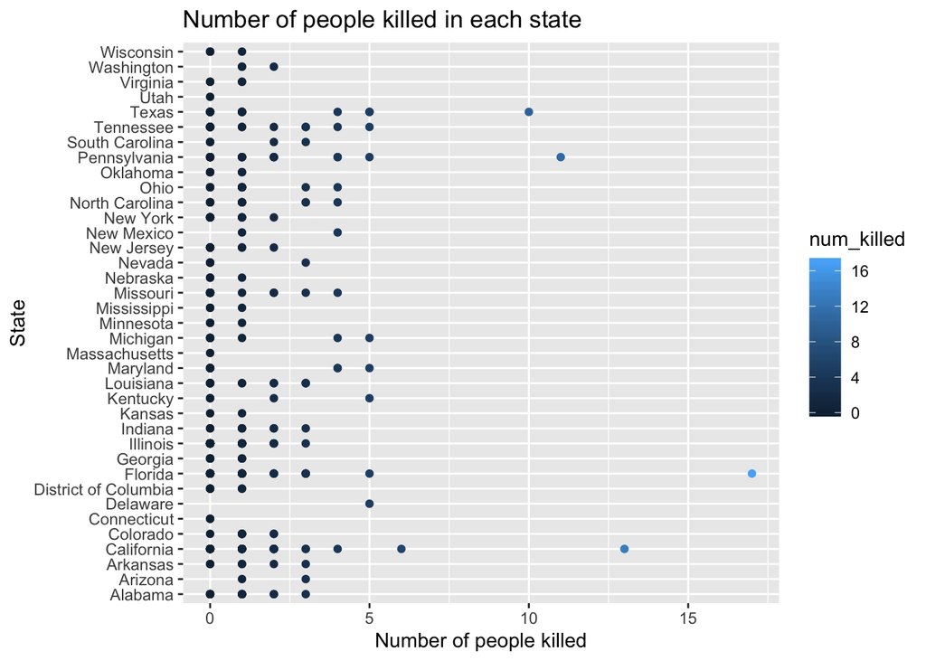

And as we can see, the the state with the highest amount of people killed was Florida, with California being a close second.

Also, there were several states that had shooting incidents, but no one died, thankfully.